# criss_cross_tutorial

#### This notebook provides two end-to-end examples of how to extract a single HETG spectrum from a crowded region and run CrissCross to handle confusion. Example (1) covers a single obsID in depth and example (2) demonstrates how to run CrissCross on multiple obsIDs and combine the resulting spectra.

#### More information and examples on crisscross and it's helper function clean_spec can be found on their respective ahelp pages (e.g., 'ahelp crisscross' and 'ahelp clean_spec').

### CrissCross Summary:

CrissCross and its helper tool clean_spec allow users to analyze Chandra High Energy Transmission Grating (HETG) spectra that are extracted from a field of view with multiple other astrophysical X-ray sources. The HETG instrument will disperse events onto the ACIS CCDs from all sources in a field of view and if there are several sufficiently-bright X-ray sources then there is a potential for 'confusion' to occur. Confusion is a term used here for special scenarios where standard HETG spectral extraction of a source may erroneously assign events (counts) from a different astrophysical source in the field of view to the extracted source. This can result in events from an unrelated astrophyscal source 'confusing' the spectrum of an extracted source.

CrissCross is used to identify when spectral confusion occurs for a list of input sources (or a single source) and generates 'confusion tables' which identify the wavelength in each source's spectrum that are likely to include X-ray events from unrelated field astrophysical sources. The user can then choose to remove all events from the source spectrum in the wavelenegth range where this confusion occurs. The CrissCross helper program clean_spec uses the CrissCross output confusion tables and input HETG PHA spectra to generate 'cleaned' spectra (and ARFs) where these events are removed. CrissCross is especially useful for crowded X-ray fields with multiple observations such as stellar clusters.

```python
from ciao_contrib.runtool import *
from sherpa.astro.ui import *
import numpy as np
import matplotlib.pyplot as plt
import os
import glob
import shutil

from load_hetg_resp import *
```

#### execute the criss_cross.py script to access functions (for now)

```python
run criss_cross.py #NEEDS TO BE UPDATED BEFORE RELEASE
```

```python
run clean_spec.py #NEEDS TO BE UPDATED BEFORE RELEASE
```

## (1) Run CrissCross for a single source on a single obsID

#### Download obsID 3, a crowded HETG observation of a pre-main sequence stellar cluster.

```python
os.system('download_chandra_obsid 3')
```

```
Downloading files for ObsId 3, total size is 522 Mb.

  Type     Format      Size  0........H.........1  Download Time Average Rate
  ---------------------------------------------------------------------------
  evt1     fits      125 Mb  ####################            8 s  15113.4 kb/s
  vvref    pdf       107 Mb    already downloaded
  evt1a    fits       96 Mb    already downloaded
  evt2     fits       27 Mb    already downloaded
  rmf      fits       18 Mb    already downloaded
  rmf      fits       18 Mb    already downloaded
  rmf      fits       18 Mb    already downloaded
  rmf      fits       17 Mb    already downloaded
  rmf      fits       17 Mb    already downloaded
  rmf      fits       17 Mb    already downloaded
  asol     fits       11 Mb  ####################          < 1 s  11621.5 kb/s
  rmf      fits        6 Mb    already downloaded
  rmf      fits        6 Mb    already downloaded
  rmf      fits        6 Mb    already downloaded
  rmf      fits        6 Mb    already downloaded
  rmf      fits        6 Mb    already downloaded
  rmf      fits        6 Mb    already downloaded
  mtl      fits        2 Mb  ####################          < 1 s  3288.6 kb/s
  stat     fits        1 Mb  ####################          < 1 s  8030.8 kb/s
  pha2     fits        1 Mb    already downloaded
  bias     fits      503 Kb  ####################          < 1 s  2803.1 kb/s
  bias     fits      448 Kb  ####################          < 1 s  5070.7 kb/s
  bias     fits      446 Kb  ####################          < 1 s  5098.7 kb/s
  bias     fits      445 Kb  ####################          < 1 s  5253.9 kb/s
  bias     fits      441 Kb  ####################          < 1 s  4982.2 kb/s
  aqual    fits      406 Kb    already downloaded
  aqual    fits      369 Kb    already downloaded
  osol     fits      363 Kb    already downloaded
  osol     fits      354 Kb    already downloaded
  osol     fits      348 Kb    already downloaded
  osol     fits      348 Kb    already downloaded
  osol     fits      348 Kb    already downloaded
  osol     fits      347 Kb    already downloaded
  osol     fits      346 Kb    already downloaded
  osol     fits      344 Kb    already downloaded
  eph1     fits      301 Kb    already downloaded
```

[output cut: 15 more lines]

```
  arf      fits      128 Kb    already downloaded
  arf      fits      128 Kb    already downloaded
  full_img jpg        60 Kb    already downloaded
  vv       pdf        56 Kb    already downloaded
  oif      fits       28 Kb    already downloaded
  bpix     fits       27 Kb  ####################          < 1 s  260.2 kb/s
  eph1     fits       19 Kb    already downloaded
  readme   ascii      10 Kb    already downloaded
  fov      fits        8 Kb  ####################          < 1 s  217.8 kb/s
  flt      fits        7 Kb  ####################          < 1 s  185.7 kb/s
  msk      fits        5 Kb  ####################          < 1 s  132.2 kb/s
  pbk      fits        4 Kb  ####################          < 1 s  92.7 kb/s

      Total download size for ObsId 3 = 142 Mb
      Total download time for ObsId 3 = 11 s
```

```
0
```

#### We will extract the spectrum of a single source in the field of view using chandra_repro and the source coordinates. COUP 394 is a young, pre-main sequence star whose X-ray emission is generated by a hot corona. The commands below will produce only responses for the +1/-1 HEG/MEG orders. Users that wish to generate all responses should use the 'tg_orders' command with chandra_repro.

#### Users that wish to see spectra from other sources in the field of view can modify the variables below before running the remaining cells

```python
#SRC NAME -- COUP 394
#83.79475306,-5.39575306,393

src_RA = 83.79475306
src_DEC = -5.39575306
obsid = 3
src_root = 'COUP_394'
```

```python
#run chandra repro using the zeroth order source location for COUP 394

chandra_repro.punlearn()
chandra_repro.indir = obsid
chandra_repro.root = src_root
chandra_repro.tg_zo_position = f'{src_RA},{src_DEC}'
chandra_repro.clobber=False

print(chandra_repro)

a = chandra_repro()
```

```
Parameters for chandra_repro:

Required parameters:
               indir = 3                Input directory
              outdir =                  Output directory (default = $indir/repro)

Optional parameters:
                root = COUP_394         Root for output filenames
            badpixel = True             Create a new bad pixel file?
      process_events = True             Create a new level=2 event file?
            destreak = True             Destreak the ACIS-8 chip?
          set_ardlib = True             Set ardlib.par with the bad pixel file?
        check_vf_pha = False            Clean ACIS background in VFAINT data?
             pix_adj = default          Pixel randomization: default|edser|none|randomize
      tg_zo_position = 83.79475306,-5.39575306  Method to determine gratings 0th order location: evt2|detect|R.A. & Dec.
         asol_update = True             If necessary, apply boresight correction to aspect solution file?
           pi_filter = True             Apply PI background filter to HRC-S+LETG data?
       patch_hrc_ssc = False            Patch HRC Secondary Science Corruption?
             cleanup = True             Cleanup intermediate files on exit
             clobber = True             Clobber existing file
             verbose = 1                Debug Level(0-5)
```

#### Lets take a look at the source's spectra using Sherpa. We can use the new sherpa-contrib function 'load_gratings_pha2' to identify and load the pipeline response files (ARFs and RMFs) use information in the PHA2 spectrum header. Since the PHA2 file has all spectra data for all 12 orders, sherpa data ids 1-12 will be used. If the directory does not include all 12 HETG responses then only those identified will be loaded.

```python
clean() #run clean in case you want to refresh this cell in a notebook

original_pha2 = f'{obsid}/repro/{src_root}_repro_pha2.fits'
load_gratings_pha2(pha2_file=original_pha2, use_errors=True)
```

```
WARNING-- The identified number of ARFs [4] does not match the number of PHA spectra [12] in the PHA2 file. Only the responses found will be included.


WARNING-- The identified number of RMFs [4] does not match the number of PHA spectra [12] in the PHA2 file. Only the responses found will be included.

read background_up into a dataset from file 3/repro/COUP_394_repro_pha2.fits
read background_down into a dataset from file 3/repro/COUP_394_repro_pha2.fits
Multiple data sets have been input: 1-12
```

#### Now that the data are loaded, we can plot the brightest orders (HEG-1, HEG+1, MEG-1, MEG+1). Since there is not much data past 20 Angstrom for this source we will limit the X-axis range.

```
dataset 3: 1:21.48 Wavelength (Angstrom)
dataset 4: 1:21.48 Wavelength (Angstrom)
dataset 9: 1:41.96 Wavelength (Angstrom)
dataset 10: 1:41.96 Wavelength (Angstrom)
dataset 3: 1:21.48 Wavelength (Angstrom) (unchanged)
dataset 4: 1:21.48 Wavelength (Angstrom) (unchanged)
dataset 9: 1:41.96 Wavelength (Angstrom) (unchanged)
dataset 10: 1:41.96 Wavelength (Angstrom) (unchanged)
```

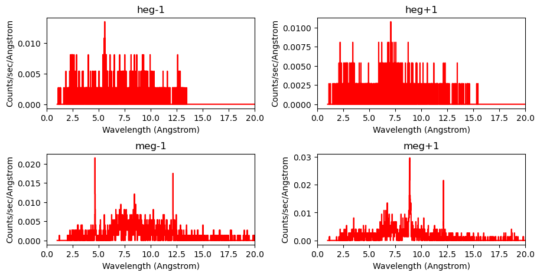

```python
#to view all four orders at once (heg +1/-1 and meg+1/-1)
spec_ids = [3,4,9,10]

#each id must be set to the 'wave' analysis to plot in angstrom (instead of keV)
for i in spec_ids:
    set_analysis(i,'wave')

bin_num=3
for i in spec_ids:
    group_width(i, bin_num)

#create an arm label for the subplot names
arm_label = ['heg-1','heg+1','meg-1','meg+1']

plt.figure(figsize=(9, 5))
plot("data", 3, "data", 4, "data", 9, "data", 10, yerrorbars=False, color='red', linestyle='-', marker=None)

plt.subplots_adjust(left=0, hspace=0.5, wspace=0.3)
axes = plt.gcf().axes

# set the same x-limits for all panels:
#for ax in axes:
for ax, arm in zip(axes,arm_label):
    ax.set_xlim(0, 20)
    ax.set_title(arm)
```

#### We can also plot the spectral response for the source using the ARF files. This shows the sensitivity of the detector at the extracted spectral location.

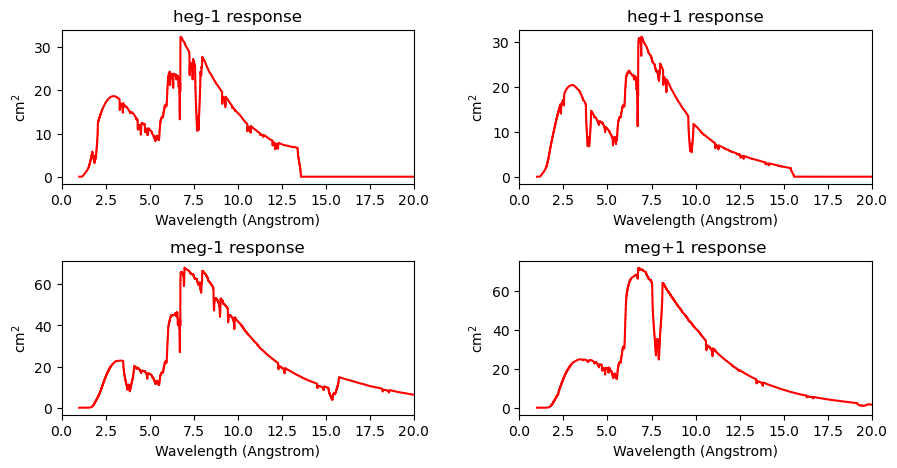

```python
#we can also plot the ARFs for each order
arm_label_arf = ['heg-1 response','heg+1 response','meg-1 response','meg+1 response']

plt.figure(figsize=(9, 5))
plot("arf", 3, "arf", 4, "arf", 9, "arf", 10, color='red')

axes = plt.gcf().axes
for ax, arm in zip(axes,arm_label_arf):
    ax.set_xlim(0, 20)
    ax.set_title(arm)

plt.subplots_adjust(left=0, hspace=0.5, wspace=0.3)
```

#### The event file can be viewed via ciao's ds9 commands:

```python
os.system(f'ds9 {obsid}/repro/{src_root}_repro_evt2.fits -scale log -bin factor 4 &')
```

```
0
```

#### The extracted source is in a crowded field and confusion should be assessed. In other words, the dispersed spectrum of COUP 394 (green ds9 region-box if viewing the event file) intersects with many sources and other dispersed spectra. To identify potential confusion we'll run CrissCross on the observation. This requires an input list of all X-ray sources potentially in the field of view.

#### I have included such a list for this tutorial (see download at top) but users will have to produce their own for other fields. Most of the Chandra HETG observations with more than a few sources in the field of view have been previously observed with Chandra imaging. Running CIAO's wavdetect on an archival non-HETG imaging observaiton is a good way to produce an easy source list. Otherwise, users will have to use another wavelength (telescope) or identify the 0th order sources in an HETG observation by eye and manually create a list.

#### An example of how to create a crisscross source list using wavdetect can be found on the crisscross ahelp page.

```python
help(run_crisscross)
#os.system('ahelp crisscross') #NEEDS TO BE UPDATED BEFORE RELEASE
```

```
Help on function run_crisscross in module __main__:

run_crisscross(evt2_file=None, cc_outdir=None, main_list=None, subset_src_list=None, single_src_pos=None, single_src_root=None, wavdetect_file=None, conf_table_level='confused', arf_ratios_dir=None, clobber_par=False, max_pntsrc_dist=8, min_pntsrc_counts=5, min_spec_counts=3, min_spec_confuser_count…
    Main function for running criss cross. CrissCross identifies portions of a sources spectrum where events from other
    field sources may be errouneously assigned to the extracted source with standard CIAO processing. CrissCross
    produces a fits table for each source which tabulates the wavelength location where confusion occurs for all HETG
    arms (heg+meg) and orders -3 to +3. CrissCross requires the evt2 file that was used to extract a source's spectra
    and a list of RA+DEC (main_list) for every X-ray source in the field of view. A list of sources in the field of
    view can often be obtained by running wavdetect on the same field if there are non-HETG archival Chandra
    observations. CrissCross can create spectral confusion tables for all sources present in a secondary
    (subset_src_list) list or can be run for a single source using the 'single_src_pos' parameter.

    If users have PHA files extracted using the relevant evt2 file they can run the complimentary CIAO tool clean_spec()
    using the CrissCross confusion tables as input to remove confused counts from their spectra and associated ARFs
    before performing their spectral analysis.

    Parameters
    ----------
    evt2_file : str
        A single evt2 file or a list of evt2 files which contain sources in main_list and subset_src_list.
    cc_outdir : str
        A directory for holding the output of CrissCross. If it does not exist then it will be made.
    main_list : str
        A tsv or ascii file with columns RA, DEC, ID of source positions. This is used to distinguish real sources in a
        wavdetect source table from false sources (identified from the dispersed spectra). This can include sources
        outside of an individual chandra obsID FOV.
    subset_src_list : str
        A tsv or ascii file of sources to create confusion tables for. This should be a subset of main_list and include
        sources bright enough for HETG spectral extraction. The table format requires columns RA, and DEC.
    single_src_pos : string
        RA and DEC position in degrees to calculate confusion for only a single source. The source coordinates must
        also be in the main_list file. Format must be J2000 degrees in format e.g., '83.8186447, -5.3896515'.
    single_src_root : string
        Root name for single_src_pos confusion table. If None then element number of main_list is used in table name.
    wavdetect_file : str, None
        A single wavdetect source fits table or a list of wavdetect source fits tables. This is the '*src.fits' file
        output from wavdetect. If no files are included (e.g., wavdetect_file=None) then wavdetect will be run during
        execution of CrissCross.
    conf_table_level : str, 'confused', 'warn', or 'clean'
        Determines the output saved in the confusion tables. 'confused': includes only the locations of confusion.
```

[output cut: 50 more lines]

```
        The minimum number of 0th order counts a confuser source can have before being considered a candidate for arm
        confusion. Note, while it depends on the spectrum, if a 0th order source has 50 counts then there are only
        approximately (1.3 * 50) = 65 dispersed counts in the sum of all arms (HEG/MEG) and orders (default: 50).
    meg_cutoff_low, meg_cutoff_high : float
        The wavelength boundaries for all confusion calculations in Angstroms. If users only care about e.g., the 5-10
        A region of meg then they can set meg_cutoff_low=5.0 and meg_cutoff_high=10.0 and only confusion that occurs
        within this wavelength region is considered. This parameter is not used for arm confusion (default: 1.0, 32.0).
    heg_cutoff_low, heg_cutoff_high : float
        The wavelength boundaries for all confusion calculations in Angstroms. If users only care about e.g., the 5-10
        A region of meg then they can set heg_cutoff_low=5.0 and heg_cutoff_high=10.0 and only confusion that occurs
        within this wavelength region is considered. This parameter is not used for arm confusion (default: 1.0, 16.0).
    min_tg_d, max_tg_d : float
        Lower and upper bounds of the spectral extraction of a dispersed spectrum in cross-dispersion direction in degrees.
        These parameters should be set to the same values used in `tg_extract` and they default
        to the default used in `tg_extract`. Crisscross assumes rectangualr extraction regions.
```

#### If you have a source list (the main_list par) then all you need for this tutorial is the evt2 file and RA/DEC of your HETG-extracted source. CrissCross will identify if any of the sources in the source list produce erroneous counts in the extracted source COUP 394. Depending on your computer and the number of sources in the source list, CrissCross could potentially take a few minutes to run.

```python
evt2_path = f'{obsid}/repro/{src_root}_repro_evt2.fits'

run_crisscross(evt2_file=evt2_path, cc_outdir='cc_tutorial', main_list='input_files/full_coup_src_list.tsv',  single_src_pos=f'{src_RA},{src_DEC}', single_src_root=src_root, clobber_par=False) #NEEDS TO BE UPDATED BEFORE RELEASE
```

```
CrissCross Time Start:
Tue Jun  9 16:59:09 2026


This run is for observation "3/repro/COUP_394_repro_evt2.fits".
This run is for observation "3/repro/COUP_394_repro_evt2.fits".

No input wavdetect source fits table provided so running wavdetect on 3/repro/COUP_394_repro_evt2.fits with binsize=2.0, bands=broad and psfecf=0.9.
If you wish to use other wavdetect parameters please run wavdetect and provide a wavdetect source fits table with parameter 'wavdetect_file'.

The total number of X-ray field sources input is 1616. These will be assessed as potential sources of confusion for sources in 'subset_src_list' or 'single_src_pos'.

total elapsed time has been 1.1 minutes.
```

#### CrissCross has finished and produced the relevant cleaning table for COUP 394. We can view the identified confusion for each arm with dmlist (or any fits table reader). Here, we only print the most relevant columns but the full table can be viewed as well.

```python
cc_table_coup = f'cc_tutorial/output_dir_obsid_3/confusion_output_files/table_fits_data/confused_{src_root}_consolidated_obsID_3.fits'

#view the sources of confusion in the COUP 394 MEG arm
dmlist.punlearn
dmlist.infile = f'{cc_table_coup}[cols confuser_srcid, grating_type, order, confusion_type, confusion_wave, wave_low, wave_high, flag][flag=confused, order=-1,+1, grating_type=meg]'
dmlist.opt='data'

dmlist()
```

```
--------------------------------------------------------------------------------
Data for Table Block TABLE
--------------------------------------------------------------------------------

ROW    confuser_srcid grating_type order      confusion_type confusion_wave       wave_low             wave_high            flag

     1        696 meg            1 spec           2.6126691536         1.9454580533         3.2798802538 confused
     2       1390 meg            1 spec           8.9880208912         8.3208097909         9.6552319914 confused
     3        187 meg            1 pnt            8.9045904665         8.7486201313         9.0605608017 confused
     4        515 meg           -1 pnt            2.6398747791         2.6172583374         2.6624912208 confused
     5        652 meg           -1 pnt            4.6294335817         4.6025095872         4.6563575761 confused
     6       1113 meg           -1 pnt           11.2665089081        11.1864092180        11.3466085981 confused
     7        187 meg           -1 arm            4.4522952332                3.970                5.180 confused
     8        187 meg           -1 arm            8.9045904665                7.290               12.750 confused
     9        187 meg            1 arm            2.2261476166                2.140                2.330 confused
    10        187 meg            1 arm            2.9681968222                2.840                3.120 confused
    11        187 meg            1 arm            4.4522952332                4.270                4.660 confused
    12        652 meg           -1 arm                     1.0               21.840               31.990 confused
    13        652 meg           -1 arm            2.3147167908                2.250                2.390 confused
    14        652 meg           -1 arm            1.5431445272                 1.50                1.590 confused
    15        652 meg            1 arm                     1.0               21.840               31.990 confused
    16        652 meg            1 arm            4.6294335817                3.980                5.770 confused
    17        652 meg            1 arm            2.3147167908                2.130                2.560 confused
    18       1113 meg           -1 arm            5.6332544540                5.380                5.930 confused
    19       1113 meg           -1 arm            3.7555029694                3.570                3.970 confused
    20       1113 meg           -1 arm            2.8166272270                2.690                2.970 confused
    21       1113 meg            1 arm            5.6332544540                4.960                 6.70 confused
```

```python
#view the sources of confusion in the COUP 394 HEG arm
dmlist.punlearn
#dmlist.infile = f'{cc_table_coup}[flag=confused, order=-1,+1, grating_type=heg]'
dmlist.infile = f'{cc_table_coup}[cols confuser_srcid, grating_type, order, confusion_type, confusion_wave, wave_low, wave_high, flag][flag=confused, order=-1,+1, grating_type=heg]'
dmlist.opt='data'
dmlist.rows='1:50'

dmlist()
```

```
--------------------------------------------------------------------------------
Data for Table Block TABLE
--------------------------------------------------------------------------------

ROW    confuser_srcid grating_type order      confusion_type confusion_wave       wave_low             wave_high            flag

     1        654 heg           -1 spec           2.2434677134         1.9098896723         2.5770457545 confused
     2        696 heg           -1 spec           2.5394510028         2.2058729617         2.8730290439 confused
     3        896 heg           -1 spec           4.0036047229         3.6700266818         4.3371827640 confused
     4       1070 heg           -1 spec           5.5581381601         5.2245601190         5.8917162012 confused
     5       1089 heg           -1 spec           5.5417734858         5.2081954447         5.8753515269 confused
     6       1198 heg           -1 spec           6.8990374745         6.5654594334         7.2326155156 confused
     7       1231 heg           -1 spec          12.7468867023        12.4133086612        13.0804647434 confused
     8       1390 heg           -1 spec           9.1588726939         8.8252946528         9.4924507350 confused
     9        225 heg            1 pnt            2.2023245108         2.1570122855         2.2476367362 confused
    10        571 heg           -1 pnt            1.1120539065     0.86905072783986         1.3612955569 confused
    11        160 heg            1 arm            1.1614327135                1.130                1.190 confused
    12        225 heg           -1 arm            1.1011622554                1.040                1.170 confused
    13        225 heg           -1 arm            2.2023245108                1.980                2.530 confused
    14        225 heg           -1 arm                    16.0               13.890               31.990 confused
    15        225 heg            1 arm            1.1011622554                1.080                1.120 confused
    16        225 heg            1 arm                    16.0               13.890               31.990 confused
```

#### We can see that CrissCross identified some confusion (flag column 'confused'). The 'wave_low' and 'wave_high' columns indicate the wavelength range recommended to be ignored due to the liklihood of HETG confusion by source 'confuser_srcid'. The 'confusion_type' column shows which of the three primary sources of confusion (point source, spectral intersection or arm confusion) has been identified. For more information on each of these types of confusion, see the crisscross ahelp page.

#### Let's clean the confused portions of the spectrum and responses using the CrissCross helper CIAO function clean_spec. NOTE: clean_spec removes ALL counts in the confused regions and not just counts from the confusing source. However, CrissCross has many tunable parameters to allow some level of potential confusion through based on the signal-to-noise ratio of the HETG source events compared to the confused events in the confused bandpass. If you find CrissCross is unnecessarily removing counts then please re-run with lower confusion threshold parameters. See the crisscross ahelp page for more info.

```python
help(clean_spec)
#os.system(ahelp clean_spec) #NEEDS TO BE UPDATED BEFORE RELEASE
```

```
Help on function clean_spec in module __main__:

clean_spec(cc_table, pha_file, spec_root, arf_file=None, resp_dir=None, clobber=False)
    Uses confusion tables produced by CrissCross to create 'cleaned' PHA1 or PHA2 spectra and ARF response files. The
    confusion tables identify portions of a source's spectrum that may have erroneous events that should not be
    included in any spectral analysis. After identifying the PHA type (1 vs 2), this function checks to make sure the
    ARF files provided match the PHA spectra (order and arm) and uses clean_data() to set the appropriate PHA
    (COUNTS, STAT_ERROR) and ARF (SPECRESP, FRACEXPO) columns to zero where confusion occurs. This function writes a
    'cleaned' copy of the input PHA and ARF files.

    Parameters
    ----------

    cc_table: fits table
        CrissCross produced confusion table for a single source and single obsID.
    pha_file: fits file
        HETG PHA1 or PHA2 spectral file of the source that needs cleaning.
    spec_root: string
        A root for file naming purposes.
    arf_file: string or list
        A file path or list of file paths to ARFs matching the input pha file.
    resp_dir: directory
        The directory where the ARFs associated with the pha_file is stored.
    clobber: Bool
        If clobber=True then output file will be over-written.
```

#### clean_spec will attempt to identify the relevant response files when provided with an HETG PHA2 file. This is important because clean_spec also zeros out the ARF for each source of confusion. The clean_spec tool creates a new 'cleaned' PHA2 file and associated ARFs and does not modify the original files. In this example, only 4 ARFs and spectra are cleaned because we only created 4 response files when running chandra repro (heg-1,+1, meg-1,+1). Even though only four orders have been cleaned, the new PHA2 file still contains the other 8 uncleaned (original) orders.

```python
clean_spec(cc_table=cc_table_coup, pha_file = original_pha2, spec_root=src_root, arf_file=None, resp_dir=None, clobber=False)
```

```
WARNING-- The identified number of ARFs [4] does not match the number of PHA spectra [12] in the PHA2 file. Only the responses found will be included.
```

```
()
```

#### clean_spec produced a new PHA2 file and four new ARF files. So lets load those into sherpa and take a look. We'll load them starting with ID 13 so we don't overwrite the previously loaded (uncleaned) spectra. We will find the responses again and load the new cleaned ARFs and the original RMFs. Note, the RMF files are not affected by confusion and thus we will use the original RMFs produced, in this case, with chandra_repro.

```python
cleaned_pha2 = f'{src_root}_obsid_{obsid}_cleaned.pha2'
load_gratings_pha2(pha2_file=cleaned_pha2, rmf_dir=f'{obsid}/repro/tg', use_errors=True, dataset_id_start=13)
```

```
WARNING-- The identified number of ARFs [4] does not match the number of PHA spectra [12] in the PHA2 file. Only the responses found will be included.


WARNING-- The identified number of RMFs [4] does not match the number of PHA spectra [12] in the PHA2 file. Only the responses found will be included.

read background_up into a dataset from file COUP_394_obsid_3_cleaned.pha2
read background_down into a dataset from file COUP_394_obsid_3_cleaned.pha2
Multiple data sets have been input: 13-24
```

#### Now that we have cleaned spectra and responses, we can view the cleaned spectra as we did before but this time overplot them on the original. This will demonstrate what CrissCross and clean_spec have done.

```
dataset 15: 1:21.48 Wavelength (Angstrom)
dataset 16: 1:21.48 Wavelength (Angstrom)
dataset 21: 1:41.96 Wavelength (Angstrom)
dataset 22: 1:41.96 Wavelength (Angstrom)
dataset 15: 1:21.48 Wavelength (Angstrom) (unchanged)
dataset 16: 1:21.48 Wavelength (Angstrom) (unchanged)
dataset 21: 1:41.96 Wavelength (Angstrom) (unchanged)
dataset 22: 1:41.96 Wavelength (Angstrom) (unchanged)
```

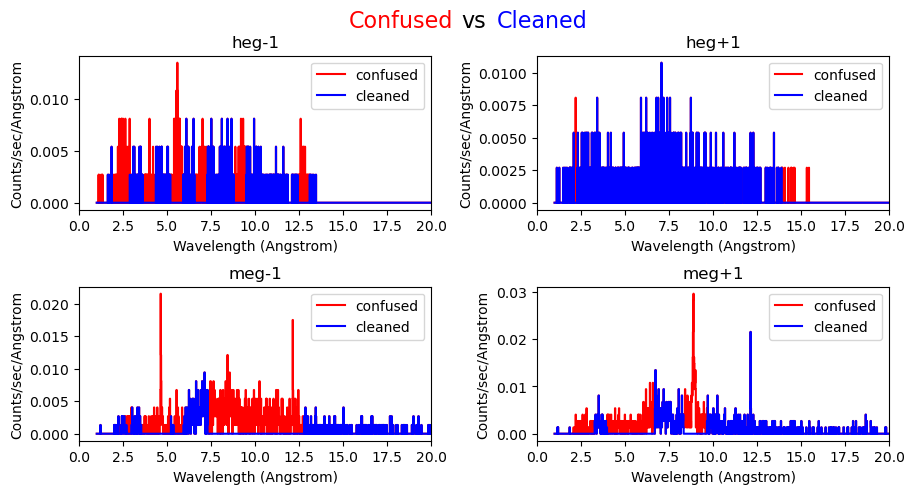

```python
#the new sherpa ids for the cleaned heg-1, heg+1, meg-1 and meg+1 spectra
spec_ids_clean = [15,16,21,22]

#set the analysis space to wavelength so it plots in Angstroms.
for i in spec_ids_clean:
    set_analysis(i,'wave')

#bin num was set in earlier cell and should be the same here
for i in spec_ids_clean:
    group_width(i, bin_num)

plt.figure(figsize=(9, 5))

#plot the original (confused) spectra in red
plot("data", 3, "data", 4, "data", 9, "data", 10, color='red',label=['confused','confused','confused','confused'], yerrorbars=False, linestyle='-', marker=None)

#overplot the new 'cleaned' spectra in blue
plot("data", 15, "data", 16, "data", 21, "data", 22, color='blue',label=['cleaned','cleaned','cleaned','cleaned'], overplot=True, yerrorbars=False, linestyle='-', marker=None)

# set the same x-limits for all panels:
axes = plt.gcf().axes
for ax, arm in zip(axes,arm_label):
    ax.set_xlim(0,20)
    ax.set_title(arm)
    ax.legend()

#label the figure with color
fig = plt.gcf()
fig.text(0.30, 0.95, "Confused",  ha='left',  va='center', color='red',  fontsize=16)
fig.text(0.425, .95, "vs",    va='center', color='black',  fontsize=16)
fig.text(0.565, .95, "Cleaned", ha='right', va='center', color='blue', fontsize=16)
plt.draw()
plt.subplots_adjust(left=0, hspace=0.5, wspace=0.3)
```

#### We can directly see the identified regions of confusion where the flux (blue) goes to zero compared to the red spectra. We can also make the similar comparison with the original (confused) and cleaned arfs:

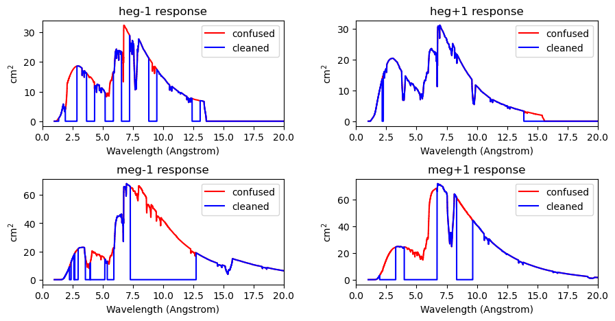

```python
plt.figure(figsize=(9, 5))
#original ARFs
plot("arf", 3, "arf", 4, "arf", 9, "arf", 10, label=['confused','confused','confused','confused'], color='red')
#cleaned ARFs
plot("arf", 15, "arf", 16, "arf", 21, "arf", 22, label=['cleaned','cleaned','cleaned','cleaned'], color='blue', overplot=True)

axes = plt.gcf().axes
for ax, arm in zip(axes,arm_label_arf):
    ax.set_xlim(0, 20)
    ax.set_title(arm)

plt.subplots_adjust(left=0, hspace=0.5, wspace=0.3)
```

#### We can see several portions of each spectrum have been identified to have events associated with other sources in the field assigned to our extracted COUP 394 source (e.g., confusion). Notice what would have appeared as emission lines now are identfied as emission from a different source. The small ranges of confusion are typically associated with point source and spectral intersection whereas the large bandpass of confusion are typically the result of arm confusion (e.g., another bright source falling on the dispersed arm of the extract source.)

#### We can double check the confusion tables to see specific instances of confusion and the source causing them. Let's look at confusion the MEG arm data.

```python
dmlist.punlearn
dmlist.infile = f'{cc_table_coup}[cols confuser_srcid, grating_type, order, confusion_type, confusion_wave, wave_low, wave_high, flag][flag=confused, order=-1,+1, grating_type=meg]'
dmlist.opt='data'
dmlist.rows=30

dmlist()
```

```
--------------------------------------------------------------------------------
Data for Table Block TABLE
--------------------------------------------------------------------------------

ROW    confuser_srcid grating_type order      confusion_type confusion_wave       wave_low             wave_high            flag

     1        696 meg            1 spec           2.6126691536         1.9454580533         3.2798802538 confused
     2       1390 meg            1 spec           8.9880208912         8.3208097909         9.6552319914 confused
     3        187 meg            1 pnt            8.9045904665         8.7486201313         9.0605608017 confused
     4        515 meg           -1 pnt            2.6398747791         2.6172583374         2.6624912208 confused
     5        652 meg           -1 pnt            4.6294335817         4.6025095872         4.6563575761 confused
     6       1113 meg           -1 pnt           11.2665089081        11.1864092180        11.3466085981 confused
     7        187 meg           -1 arm            4.4522952332                3.970                5.180 confused
     8        187 meg           -1 arm            8.9045904665                7.290               12.750 confused
     9        187 meg            1 arm            2.2261476166                2.140                2.330 confused
    10        187 meg            1 arm            2.9681968222                2.840                3.120 confused
    11        187 meg            1 arm            4.4522952332                4.270                4.660 confused
    12        652 meg           -1 arm                     1.0               21.840               31.990 confused
    13        652 meg           -1 arm            2.3147167908                2.250                2.390 confused
    14        652 meg           -1 arm            1.5431445272                 1.50                1.590 confused
    15        652 meg            1 arm                     1.0               21.840               31.990 confused
    16        652 meg            1 arm            4.6294335817                3.980                5.770 confused
    17        652 meg            1 arm            2.3147167908                2.130                2.560 confused
    18       1113 meg           -1 arm            5.6332544540                5.380                5.930 confused
    19       1113 meg           -1 arm            3.7555029694                3.570                3.970 confused
    20       1113 meg           -1 arm            2.8166272270                2.690                2.970 confused
    21       1113 meg            1 arm            5.6332544540                4.960                 6.70 confused
```

#### From the table, it appears that the MEG+1 wavelength range of ~8-9.5 A is affected by two sources of confusion. A 0th order point source (COUP 187) landed right on the dispersed spectrum and the dispersed spectrum of COUP 1390 also intersected with the extracted MEG+1 spectrum.

#### Lets take a closer look at the events assigned to the HEG or MEG spectrum to visually assess how well CrissCross identified confusion. This plotting method only works on evt2 files made for the extracted source of interest which in this case is COUP 394. Here we can see what information is available in a typical HETG evt2 file.

```python
#use pycrates to read in the event file and inspect the columns
from pycrates import read_file

evt2_file = f'{obsid}/repro/{src_root}_repro_evt2.fits'
evt_data = read_file(evt2_file)
evt_data.get_colnames()
```

```
['time',
 'expno',
 'rd(tg_r, tg_d)',
 'chip(chipx, chipy)',
 'tdet(tdetx, tdety)',
 'det(detx, dety)',
 'sky(x, y)',
 'ccd_id',
 'pha',
 'pi',
 'energy',
 'grade',
 'fltgrade',
 'node_id',
 'tg_m',
 'tg_lam',
 'tg_mlam',
 'tg_srcid',
 'tg_part',
 'tg_smap',
 'status']
```

#### We will save the relevant HETG event values to new arrays for plotting. HETG event files contain extra columns for events associated with the extracted spectrum compared to ACIS imaging observations.

```python
#the HETG wavelength assigned to each event
tg_lam = evt_data.tg_lam.values
#the cross-dispersion distance (distance from 0th order) of each event
tg_d = evt_data.rd.tg_d.values
#the order (e.g., +1,-1) assigned to each event
tg_m = evt_data.tg_m.values
#the order times the wavelength for each event
tg_mlam = evt_data.tg_mlam.values
#the ACIS CCD-derived energy of the event
energy = evt_data.energy.values
```

```python
def filter_evt_crate(evt_crate, order_val, arm_par, tgd_par):
    """
    Function for filtering a crate evt file to return the event rows that satisfy the HETG order, arm type (meg/heg) and tg_d value conditions.
    """
    crate_elements = np.where( (evt_crate.tg_m.values == order_val) & (evt_crate.tg_part.values == arm_par) & (np.abs(evt_crate.rd.tg_d.values) < tgd_par) )

    return(crate_elements)
```

### Here we filter the event file to retrieve order- and arm-specific event information for plotting.

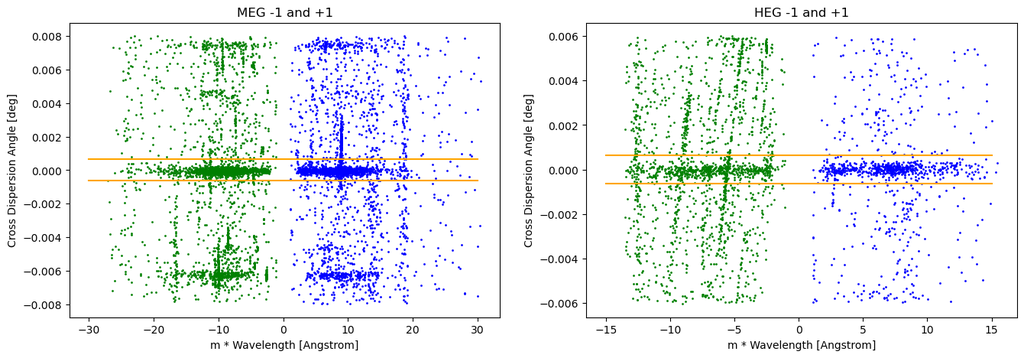

```python
#create the filters for plotting only the relevant orders and arm type
meg_p1 = filter_evt_crate(evt_data, 1, 2, 8E-3)
meg_m1 = filter_evt_crate(evt_data,-1, 2, 8E-3)
heg_p1 = filter_evt_crate(evt_data, 1, 1, 8E-3)
heg_m1 = filter_evt_crate(evt_data, -1, 1, 8E-3)

fig, ax = plt.subplots(
    nrows=1, ncols=2,                # 2 rows, 2 columns
    figsize=(16, 5),                # optional: figure size in inches
)

#MEG PLOT
ax[0].scatter(-1*tg_lam[meg_m1], tg_d[meg_m1], s=1, color='green')
ax[0].scatter(tg_lam[meg_p1], tg_d[meg_p1], s=1, color='blue')
ax[0].plot([-30,30], [6.4E-4, 6.4E-4], color='orange') #default extraction width for HETG spectra
ax[0].plot([-30,30], [-6.4E-4, -6.4E-4], color='orange')
ax[0].set_title('MEG -1 and +1')

#HEG PLOT
ax[1].scatter(-1*tg_lam[heg_m1], tg_d[heg_m1], s=1, color='green')
ax[1].scatter(tg_lam[heg_p1], tg_d[heg_p1], s=1, color='blue')
ax[1].set_title('HEG -1 and +1')
ax[1].plot([-15,15], [6.4E-4, 6.4E-4], color='orange')
ax[1].plot([-15,15], [-6.4E-4, -6.4E-4], color='orange')

for i in ax:
    i.set_xlabel('m * Wavelength [Angstrom]')
    i.set_ylabel('Cross Dispersion Angle [deg]')
```

#### The above plot shows the MEG (left) and HEG (right) events associated with the CIAO extraction of COUP 394 source. Specifically, the events within the orange box will be those that are included in the PHA2 spectrum. The X-axis denotes the order (1 or -1) * wavelength and the y-axis denotes the cross dispersion angle (tg_d) in degrees. This y-axis value is essentially denotes the counts above and below the 'line' of the dispersed spectrum.

#### A single unconfused source should only show a 'bar' of events within the orange box. On the MEG+1 plot (right, blue) you can see a strong vertical line at about 9 Angstroms which is the location of a 0th order (point source) field star that happend to fall on the dispersed spectrum of our extracted source. The vertical nature of this feature is due to the size of the PSF of that source and many of those 0th-order events were the appropriate energy (e.g., 9 A) to erroneously be assigned to the MEG+1 spectrum of COUP 394. Other fainter 0th-order confusing sources can be seen in MEG-1 at approximately -11 and -5 A. The two large horizontal features shown in the MEG plot at y~0.008 and -0.006 represent the dispersed spectra of other stars in the field which are close to the extracted source. However, only events with a small range in cross dispersion angle (~+/- 6.3E-4) and assigned to the extracted source with CIAO tools.

#### The HEG -1 plot shows many examples of spectral-intersection confusion (e.g., the dispersed arm of another source overlapping the extracted source at the wavelength expected by ACIS order sorting). These are denoted with slanted lines at approximately -6.5 and -9 A.

#### The format of this plot is difficult to use to assess arm confusion so lets look at the data now but with the y-axis as the ACIS-resolved CCD energy.

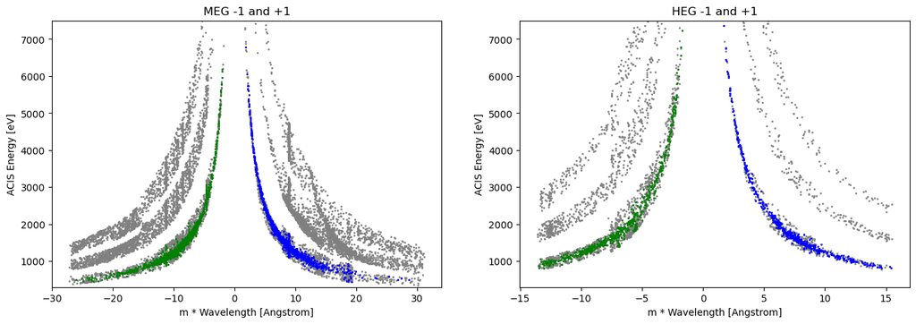

```python
#REDO the filtering with a smaller tg_d window to remove events outside default HETG extraction window
meg_p1 = filter_evt_crate(evt_data, 1, 2, 4.6E-4)
meg_m1 = filter_evt_crate(evt_data,-1, 2, 4.6E-4)
heg_p1 = filter_evt_crate(evt_data, 1, 1, 4.6E-4)
heg_m1 = filter_evt_crate(evt_data, -1, 1, 4.6E-4)

#display all events assigned to orders -3,-2,-1,+1,+2,+3
all_evts_meg_filt = np.where( (np.abs(evt_data.tg_m.values) <= 3) & (evt_data.tg_part.values == 2) )
all_evts_heg_filt = np.where( (np.abs(evt_data.tg_m.values) <= 3 ) & (evt_data.tg_part.values == 1) )


# Create a 2×2 figure (4 sub‑plots)
fig, ax = plt.subplots(
    nrows=1, ncols=2,                # 2 rows, 2 columns
    figsize=(16, 5),                # optional: figure size in inches
)

ax[0].scatter(tg_mlam[all_evts_meg_filt], energy[all_evts_meg_filt], s=1, color='grey')
ax[0].scatter(tg_mlam[meg_m1], energy[meg_m1], s=1, color='green')
ax[0].scatter(tg_mlam[meg_p1], energy[meg_p1], s=1, color='blue')
ax[0].set_title('MEG -1 and +1')


ax[1].scatter(tg_mlam[all_evts_heg_filt], energy[all_evts_heg_filt], s=1, color='grey')
ax[1].scatter(tg_mlam[heg_m1], energy[heg_m1], s=1, color='green')
ax[1].scatter(tg_mlam[heg_p1], energy[heg_p1], s=1, color='blue')
ax[1].set_title('HEG -1 and +1')

for i in ax:
    i.set_ylim(300,7500)
    i.set_xlabel('m * Wavelength [Angstrom]')
    i.set_ylabel('ACIS Energy [eV]')
```

#### Looking closer at the MEG+1 portion of the spectrum you can see the previously discussed 'point source confusion' at ~9 A. Note how it is a vertical bar in all three positive orders because the 0th order contains events over a much larger portion of ACIS CCD energy compared to the wavelength space at 9 A. Also note the curved feature starting at ~13 A in the MEG+3 order (grey) and bending ultimately towards the MEG+1 order at ~ 20 A. This is a clear indication of arm confusion from a source somewhere else on the detector but in line with the dispersed spectrum of our extracted source. The confusing source would likely contaminate all portions of the MEG+1 spectrum >~ 20.

#### CrissCross and its helper tool clean_spec facilitate the analysis of spectra from crowded HETG fields. The next and final step would be to fit the spectra with a model and learn somethign about the underlying astrophysics. This is beyond the scope of this tutorial but there are other CIAO tools that help with this process.

## (2) Run CrissCross for a single source on multiple obsIDs and combine the spectra

#### Most HETG observations are campaigns with multiple obsIDs. CrissCross excels at running over a large number of observations and producing confusion tables for multiple source in every obsID. Users should see the crisscross and clean_spec ahelp files for more examples of how this is done. Here we show how to assess confusion for a single source over multiple obsIDs.

#### Let's download two more Orion Nebula Cluster pre-main sequence star observations and re-process them so chandra_repro extracts spectra of COUP 394.

```python
#NOTE -- we will still use obsID 3 from above but intentionally not re-download it here.
obsid_list = [22999, 23000]

for i in obsid_list:
    os.system(f'download_chandra_obsid {i}')
```

```
Downloading files for ObsId 22999, total size is 414 Mb.

  Type     Format      Size  0........H.........1  Download Time Average Rate
  ---------------------------------------------------------------------------
  evt1     fits       92 Mb  ####################            9 s  10746.4 kb/s
  vvref    pdf        71 Mb    already downloaded
  evt1a    fits       70 Mb    already downloaded
  evt2     fits       21 Mb    already downloaded
  rmf      fits       18 Mb    already downloaded
  rmf      fits       18 Mb    already downloaded
  rmf      fits       18 Mb    already downloaded
  rmf      fits       17 Mb    already downloaded
  rmf      fits       17 Mb    already downloaded
  rmf      fits       17 Mb    already downloaded
  asol     fits        8 Mb  ####################          < 1 s  10449.1 kb/s
  rmf      fits        6 Mb    already downloaded
  rmf      fits        6 Mb    already downloaded
  rmf      fits        6 Mb    already downloaded
  rmf      fits        6 Mb    already downloaded
  rmf      fits        6 Mb    already downloaded
  rmf      fits        6 Mb    already downloaded
  mtl      fits        1 Mb  ####################          < 1 s  9625.7 kb/s
  stat     fits        1 Mb  ####################          < 1 s  5449.3 kb/s
  pha2     fits        1 Mb    already downloaded
  aqual    fits      522 Kb    already downloaded
  bias     fits      498 Kb  ####################          < 1 s  5451.6 kb/s
  bias     fits      466 Kb  ####################          < 1 s  5734.0 kb/s
  bias     fits      444 Kb  ####################          < 1 s  5441.7 kb/s
  bias     fits      443 Kb  ####################          < 1 s  5342.9 kb/s
  bias     fits      432 Kb  ####################          < 1 s  2585.4 kb/s
  osol     fits      364 Kb    already downloaded
  osol     fits      360 Kb    already downloaded
  osol     fits      349 Kb    already downloaded
  osol     fits      347 Kb    already downloaded
  osol     fits      347 Kb    already downloaded
  osol     fits      346 Kb    already downloaded
  eph1     fits      311 Kb    already downloaded
  eph1     fits      305 Kb    already downloaded
  eph1     fits      279 Kb    already downloaded
  vv       pdf       277 Kb    already downloaded
```

[output cut: 82 more lines]

```
  arf      fits      123 Kb    already downloaded
  full_img jpg        62 Kb    already downloaded
  vv       pdf        46 Kb    already downloaded
  oif      fits       28 Kb    already downloaded
  bpix     fits       20 Kb  ####################          < 1 s  79.6 kb/s
  osol     fits       19 Kb    already downloaded
  eph1     fits       17 Kb    already downloaded
  readme   ascii      10 Kb    already downloaded
  fov      fits        7 Kb  ####################          < 1 s  28.8 kb/s
  flt      fits        5 Kb  ####################          < 1 s  41.7 kb/s
  msk      fits        5 Kb  ####################          < 1 s  48.8 kb/s
  pbk      fits        4 Kb  ####################          < 1 s  108.6 kb/s

      Total download size for ObsId 23000 = 107 Mb
      Total download time for ObsId 23000 = 11 s
```

```python
#run chandra repro using the zeroth order source location for COUP 394

for i in obsid_list:
    chandra_repro.punlearn()
    chandra_repro.indir = i
    chandra_repro.root = src_root
    chandra_repro.tg_zo_position = f'{src_RA},{src_DEC}'
    chandra_repro.clobber=False

    print(chandra_repro)

    a = chandra_repro()
```

```
Parameters for chandra_repro:

Required parameters:
               indir = 22999            Input directory
              outdir =                  Output directory (default = $indir/repro)

Optional parameters:
                root = COUP_394         Root for output filenames
            badpixel = True             Create a new bad pixel file?
      process_events = True             Create a new level=2 event file?
            destreak = True             Destreak the ACIS-8 chip?
          set_ardlib = True             Set ardlib.par with the bad pixel file?
        check_vf_pha = False            Clean ACIS background in VFAINT data?
             pix_adj = default          Pixel randomization: default|edser|none|randomize
      tg_zo_position = 83.79475306,-5.39575306  Method to determine gratings 0th order location: evt2|detect|R.A. & Dec.
         asol_update = True             If necessary, apply boresight correction to aspect solution file?
           pi_filter = True             Apply PI background filter to HRC-S+LETG data?
       patch_hrc_ssc = False            Patch HRC Secondary Science Corruption?
             cleanup = True             Cleanup intermediate files on exit
             clobber = True             Clobber existing file
             verbose = 1                Debug Level(0-5)
Parameters for chandra_repro:

Required parameters:
               indir = 23000            Input directory
              outdir =                  Output directory (default = $indir/repro)

Optional parameters:
                root = COUP_394         Root for output filenames
            badpixel = True             Create a new bad pixel file?
      process_events = True             Create a new level=2 event file?
            destreak = True             Destreak the ACIS-8 chip?
          set_ardlib = True             Set ardlib.par with the bad pixel file?
        check_vf_pha = False            Clean ACIS background in VFAINT data?
             pix_adj = default          Pixel randomization: default|edser|none|randomize
      tg_zo_position = 83.79475306,-5.39575306  Method to determine gratings 0th order location: evt2|detect|R.A. & Dec.
         asol_update = True             If necessary, apply boresight correction to aspect solution file?
           pi_filter = True             Apply PI background filter to HRC-S+LETG data?
       patch_hrc_ssc = False            Patch HRC Secondary Science Corruption?
             cleanup = True             Cleanup intermediate files on exit
             clobber = True             Clobber existing file
             verbose = 1                Debug Level(0-5)
```

#### Instead of running CrissCross with a single evt2 file, here we will use a list of the three obsIDs that we have downloaded. They are identfied with glob.

```python
#create a list of evt2 files
evt2_list = glob.glob(f'*/repro/{src_root}_repro_evt2.fits')
print(evt2_list)
```

```
['22999/repro/COUP_394_repro_evt2.fits', '3/repro/COUP_394_repro_evt2.fits', '23000/repro/COUP_394_repro_evt2.fits']
```

#### We will save the CrissCross output to a new directory.

```python
run_crisscross(evt2_file=evt2_list, cc_outdir='cc_tutorial_multiobs', main_list='input_files/full_coup_src_list.tsv',  single_src_pos=f'{src_RA},{src_DEC}', single_src_root=src_root, clobber_par=False)
```

```
CrissCross Time Start:
Tue Jun  9 17:09:50 2026


This run is for observation "22999/repro/COUP_394_repro_evt2.fits".
This run is for observation "22999/repro/COUP_394_repro_evt2.fits".

No input wavdetect source fits table provided so running wavdetect on 22999/repro/COUP_394_repro_evt2.fits with binsize=2.0, bands=broad and psfecf=0.9.
If you wish to use other wavdetect parameters please run wavdetect and provide a wavdetect source fits table with parameter 'wavdetect_file'.

The total number of X-ray field sources input is 1616. These will be assessed as potential sources of confusion for sources in 'subset_src_list' or 'single_src_pos'.

total elapsed time has been 1.19 minutes.



CrissCross Time Start:
Tue Jun  9 17:11:01 2026


This run is for observation "3/repro/COUP_394_repro_evt2.fits".

No input wavdetect source fits table provided so running wavdetect on 3/repro/COUP_394_repro_evt2.fits with binsize=2.0, bands=broad and psfecf=0.9.
If you wish to use other wavdetect parameters please run wavdetect and provide a wavdetect source fits table with parameter 'wavdetect_file'.

The total number of X-ray field sources input is 1616. These will be assessed as potential sources of confusion for sources in 'subset_src_list' or 'single_src_pos'.

total elapsed time has been 1.03 minutes.



CrissCross Time Start:
Tue Jun  9 17:12:04 2026


This run is for observation "23000/repro/COUP_394_repro_evt2.fits".

No input wavdetect source fits table provided so running wavdetect on 23000/repro/COUP_394_repro_evt2.fits with binsize=2.0, bands=broad and psfecf=0.9.
If you wish to use other wavdetect parameters please run wavdetect and provide a wavdetect source fits table with parameter 'wavdetect_file'.

The total number of X-ray field sources input is 1616. These will be assessed as potential sources of confusion for sources in 'subset_src_list' or 'single_src_pos'.

total elapsed time has been 0.92 minutes.
```

#### To run clean_spec on multiple pha2 files we need to provide a list of pha2_files and the relevant crisscross confusion table files. We will save the cleaned spectra to a new directory.

```python
pha2_list = sorted(glob.glob(f'*/repro/{src_root}_repro_pha2.fits'))
cc_table_list = sorted(glob.glob(f'cc_tutorial_multiobs/*/*/table_fits_data/*.fits'))

spec_dir = 'coup394_multiobs_spec'
os.makedirs(spec_dir ,exist_ok=True)

for i in range(0,len(pha2_list)):
    clean_spec(cc_table=cc_table_list[i], pha_file = pha2_list[i], spec_root=f'{spec_dir}/{src_root}', arf_file=None, resp_dir=None, clobber=False)
```

```
WARNING-- The identified number of ARFs [4] does not match the number of PHA spectra [12] in the PHA2 file. Only the responses found will be included.


WARNING-- The identified number of ARFs [4] does not match the number of PHA spectra [12] in the PHA2 file. Only the responses found will be included.


WARNING-- The identified number of ARFs [4] does not match the number of PHA spectra [12] in the PHA2 file. Only the responses found will be included.
```

#### Now that we have a set of cleaned spectra from three obsIDs, lets combine them with the CIAO tool combine_grating_spectra. This is useful for visualization purposes because it can combine multiple spectra of the same source from different obsIDs. It can also combine the +1-1 orders of the same arm. It should be noted that it is typically not best practice to fit combined spectra. Instead, users are encouraged to perform joint-fits on the individual spectra and use the combining for visualization purposes. Moreover, caution should be taken when combining spectra from sources that undergo significant variability.

#### Let's start by combining the original spectra from the chandra_repro reprocessing.

```python
#make a directory to hold the combine_grating_spectra combined files.
comb_spec = 'combined_spec'
os.makedirs(comb_spec, exist_ok=True)

#combine the original 'confused' spectra
combine_grating_spectra.punlearn()
combine_grating_spectra.infile=f'*/repro/{src_root}*_pha2.fits'
combine_grating_spectra.arf=f'*/repro/tg/*.arf'
combine_grating_spectra.rmf=f'*/repro/tg/*.rmf'
combine_grating_spectra.outroot=f'{comb_spec}/{src_root}_original'
combine_grating_spectra.add_plusminus='yes'
combine_grating_spectra.order=1
combine_grating_spectra.clobber=False

print(combine_grating_spectra)

a = combine_grating_spectra()
```

```
Parameters for combine_grating_spectra:

Required parameters:
              infile = */repro/COUP_394*_pha2.fits  Source PHA1/PHA2 grating spectra to combine; enter list or '@stack'
             outroot = combined_spec/COUP_394_original  Root name for output file(s)

Optional parameters:
       add_plusminus = True             Combine +/- orders (yes) after summing signed-order and part?
                garm = all              Grating arm (HEG, MEG, LEG, or 'all')
               order = 1                Grating diffraction order (1,2,3,-1,-2,-3, or 'all')
                 arf = */repro/tg/*.arf  Source ARF files to combine; enter list or '@stack'
                 rmf = */repro/tg/*.rmf  Source RMF files to combine; enter list or '@stack'
             bkg_pha =                  Background PHA files to combine; enter list or '@stack'
       bscale_method = counts           How are BACKSCAL and background counts computed?
       exposure_mode = sum              Sum or average exposure times?
              object =                  Specify the OBJECT keyword in the combined output
             clobber = True             OK to overwrite existing output file?
             verbose = 1                Debug Level(0-5)
```

#### Unfortunately, combine_grating_spectra looks for rmfs in the same directory structure as the PHA2 files so we will have to copy the original RMFs to the new 'cleaned' directory to combine all the cleaned files and responses. This is typically not a big deal but RMFs can be relatively large files so if you are working with many observations then disk space should be considered.

```python
#ID the original RMFs and make a copy in the spec_dir
rmf_list = sorted(glob.glob(f'*/repro/tg/*.rmf'))
print(rmf_list)

for i in rmf_list:
    shutil.copy2(i, spec_dir)
```

```
['22999/repro/tg/COUP_394_repro_heg_m1.rmf', '22999/repro/tg/COUP_394_repro_heg_p1.rmf', '22999/repro/tg/COUP_394_repro_meg_m1.rmf', '22999/repro/tg/COUP_394_repro_meg_p1.rmf', '23000/repro/tg/COUP_394_repro_heg_m1.rmf', '23000/repro/tg/COUP_394_repro_heg_p1.rmf', '23000/repro/tg/COUP_394_repro_meg_…
```

```python
#combine the cleaned spectra
combine_grating_spectra.punlearn()
combine_grating_spectra.infile=f'{spec_dir}/*.pha2'
combine_grating_spectra.arf=f'{spec_dir}/*.arf'
combine_grating_spectra.rmf=f'{spec_dir}/*.rmf'
combine_grating_spectra.outroot=f'{comb_spec}/{src_root}_cleaned'
combine_grating_spectra.add_plusminus='yes'
combine_grating_spectra.order=1
combine_grating_spectra.clobber=False

print(combine_grating_spectra)

a = combine_grating_spectra()
```

```
Parameters for combine_grating_spectra:

Required parameters:
              infile = coup394_multiobs_spec/*.pha2  Source PHA1/PHA2 grating spectra to combine; enter list or '@stack'
             outroot = combined_spec/COUP_394_cleaned  Root name for output file(s)

Optional parameters:
       add_plusminus = True             Combine +/- orders (yes) after summing signed-order and part?
                garm = all              Grating arm (HEG, MEG, LEG, or 'all')
               order = 1                Grating diffraction order (1,2,3,-1,-2,-3, or 'all')
                 arf = coup394_multiobs_spec/*.arf  Source ARF files to combine; enter list or '@stack'
                 rmf = coup394_multiobs_spec/*.rmf  Source RMF files to combine; enter list or '@stack'
             bkg_pha =                  Background PHA files to combine; enter list or '@stack'
       bscale_method = counts           How are BACKSCAL and background counts computed?
       exposure_mode = sum              Sum or average exposure times?
              object =                  Specify the OBJECT keyword in the combined output
             clobber = True             OK to overwrite existing output file?
             verbose = 1                Debug Level(0-5)
```

#### We can load the COUP 394 spectra combined from three obsIDs into sherpa and plot the comparison of the confused vs cleaned spectra again.

```python
orig_heg = f'{comb_spec}/COUP_394_original_combo_heg_abs1.pha'
orig_meg = f'{comb_spec}/COUP_394_original_combo_meg_abs1.pha'
cleaned_heg = f'{comb_spec}/COUP_394_cleaned_combo_heg_abs1.pha'
cleaned_meg = f'{comb_spec}/COUP_394_cleaned_combo_meg_abs1.pha'

#run clean so we can override the previous example's sherpa environment
clean()
load_data(1,orig_heg, use_errors=True)
load_data(2,orig_meg, use_errors=True)
load_data(3,cleaned_heg, use_errors=True)
load_data(4,cleaned_meg, use_errors=True)
```

```
read ARF file combined_spec/COUP_394_original_combo_heg_abs1.arf
read RMF file combined_spec/COUP_394_original_combo_heg_abs1.rmf
read background file combined_spec/COUP_394_original_combo_heg_abs1_bkg.pha
read ARF file combined_spec/COUP_394_original_combo_meg_abs1.arf
read RMF file combined_spec/COUP_394_original_combo_meg_abs1.rmf
read background file combined_spec/COUP_394_original_combo_meg_abs1_bkg.pha
read ARF file combined_spec/COUP_394_cleaned_combo_heg_abs1.arf
read RMF file combined_spec/COUP_394_cleaned_combo_heg_abs1.rmf
read background file combined_spec/COUP_394_cleaned_combo_heg_abs1_bkg.pha
read ARF file combined_spec/COUP_394_cleaned_combo_meg_abs1.arf
read RMF file combined_spec/COUP_394_cleaned_combo_meg_abs1.rmf
read background file combined_spec/COUP_394_cleaned_combo_meg_abs1_bkg.pha
```

```
dataset 1: 1:21.48 Wavelength (Angstrom)
dataset 2: 1:41.96 Wavelength (Angstrom)
dataset 3: 1:21.48 Wavelength (Angstrom)
dataset 4: 1:41.96 Wavelength (Angstrom)
dataset 1: 1:21.48 Wavelength (Angstrom) (unchanged)
dataset 2: 1:41.96 Wavelength (Angstrom) (unchanged)
dataset 3: 1:21.48 Wavelength (Angstrom) (unchanged)
dataset 4: 1:41.96 Wavelength (Angstrom) (unchanged)
```

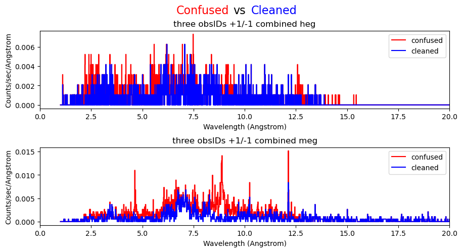

```python
#the sherpa ids of the combined datasets
combined_specs = [1,2,3,4]

#set the analysis to wavelength so we can plot in Angstrom
for i in combined_specs:
    set_analysis(i, 'wave')

#bin the counts up for visualization purposes
bin_num_comb=3
for i in combined_specs:
    group_width(i, bin_num_comb)

#setup the combined arm labels for plotting
arm_label_comb = ['three obsIDs +1/-1 combined heg','three obsIDs +1/-1 combined meg']

plt.figure(figsize=(9, 5))

#plot the original (confused) HEG and MEG spectra in red
plot("data", 1, "data", 2, color='red',label=['confused','confused'], yerrorbars=False, linestyle='-', marker=None)

#overplot the new 'cleaned' HEG and MEG spectra in blue
plot("data", 3, "data", 4, color='blue',label=['cleaned','cleaned'], overplot=True, yerrorbars=False, linestyle='-', marker=None)

# set the same x-limits for all panels:
axes = plt.gcf().axes
for ax, arm in zip(axes,arm_label_comb):
    ax.set_xlim(0,20)
    ax.set_title(arm)

#label the figure with color
fig = plt.gcf()
fig.text(0.30, 0.96, "Confused",  ha='left',  va='center', color='red',  fontsize=16)
fig.text(0.425, .96, "vs",    va='center', color='black',  fontsize=16)
fig.text(0.565, .96, "Cleaned", ha='right', va='center', color='blue', fontsize=16)
plt.draw()
plt.subplots_adjust(left=0, hspace=0.5, wspace=0.3)
```

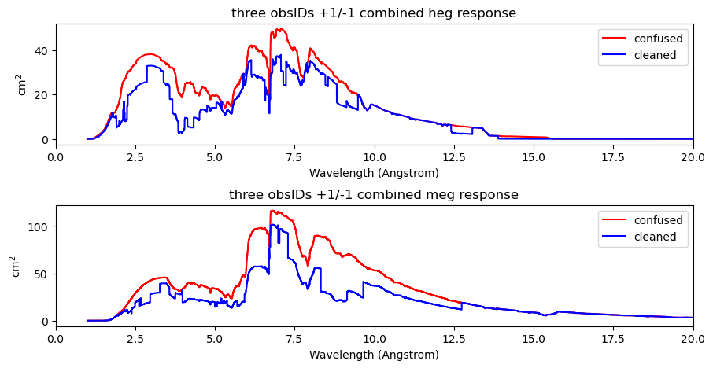

```python
arm_label_comb_arf = ['three obsIDs +1/-1 combined heg response','three obsIDs +1/-1 combined meg response']

plt.figure(figsize=(9, 5))
#original ARFs
plot("arf", 1, "arf", 2, label=['confused','confused'], color='red')
#cleaned ARFs
plot("arf", 3, "arf", 4, label=['cleaned','cleaned'],color='blue', overplot=True)

axes = plt.gcf().axes
for ax, arm in zip(axes,arm_label_comb_arf):
    ax.set_xlim(0, 20)
    ax.set_title(arm)

plt.subplots_adjust(left=0, hspace=0.5, wspace=0.3)
```

#### As you increase exposure time with multiple obsIDs, more emission lines are visible for COUP 394. Also note how the **combined** response does not go to zero because confusion does not occur at the same spot in all obsIDs due to roll angle variations and source variability. Multiple observations can be used to mitigate confusion in crowded regions.This comparison of the original (confused) data with the cleaned data demonstrate the necessity to account for confusion from other sources in the field of view.

#### For questions, comments or suggestions about CrissCross and its functionality, please contact the CXC helpdesk or principe@space.mit.edu.